# Socioeconomic Factors and Education

| *Techniques Used:* | *Linear Regression, Box/Violin Plots* |  |
| --- | --- | --- |
| *Dataset Used:* | *EdFacts (Aggregate of US Census, NCES, et. al.)* |  |
| *Technical Stack Used:* | *R (tidyverse, ggplot)* |  |

### Abstract

In this week’s project we perform a cursory analysis of publicly available education records. Specifically, we show the influence of SES (Socioeconomic Status) on academic performance as measured by math proficiency scores at the high school level. Our main takeaways are that economic status, race, and sex have small but notable relationships with performance.

### Introduction and Objective

Many publications in education research highlight the impact of socioeconomic status on education outcomes. The general consensus being that a student’s academic performance[^1] is often influenced by their background. The objective of this week’s mini-project is to explore some of those relationships first hand.

As a means of providing some structure to this analysis, we will loosely follow CRISP-DM:

- **[Business Understanding]:** The “business” value of our analysis can be interpreted as costs and benefits. Our cost is the time invested in the analysis. Our benefits are technical skill gain and an increased understanding of the problem space.
- **[Data Understanding]:** We will need to perform some preliminary work to inventory the data used. More specifically, we want to identify variables that relate to SES (gender, race, etc.) and academic performance (math proficiency, reading proficiency, etc.)
- **[Data Preparation]:** The dataset in question will likely require some adjustments to be suitable for modeling. Common tasks include outlier identification and null value removal.
- **[Modeling]:** Our intended models are linear regressions, which are nicely suited to evaluating relationships between variables.
- **[Evaluation]:** Given the limited scope of this project (one week), the evaluation process is likely to be a matter of meeting the author’s expectations.
- **[Deployment]:** The project will be concluded when it’s published to the Mini-Project Sequence website. Any subsequent updates are likely to be in their own post.

### Data Understanding / Preparation

Our dataset comes from [The Urban Institue](https://educationdata.urban.org/data-explorer/), an organization that provides data aggregates from sources such as the U.S. Census and National Center for Education Statistics. We pull records at the school level from the [EdFacts subset](https://educationdata.urban.org/documentation/schools.html#edfacts-state-assessments-by-grade).

*Data Size*

| Original File Size: | 583 MB |
| --- | --- |
| Original File Type: | CSV |
| Original File Shape: | 26 Columns x 4,069,382 Rows |
| Original File Scope: | US School Information from 2017 |

A ~600 MB flat file is right on the edge of what we might convert into a SQLite database. It’s large enough that many text editors will struggle to open it. But, given that we expect to lose some size from data munging, it’s probably fine to use as-is.

*Data Characteristics*

The records represent state assessments of proficiency. Consistency between states is not guaranteed (i.e. what Idaho considers “proficient” may not be what Oregon considers “proficient”), nor is consistency between years. For our purposes we will be working with a single year of records narrowed down to a subset of relevant columns.

```
##    leaid_num            fips             race            sex
##  Min.   : 100005   Min.   : 1.00   Total   :98815   Total  :108373
##  1st Qu.:1000190   1st Qu.:10.00   White   :15699   Male   : 18202
##  Median :2721420   Median :27.00   Hispanic:11363   Female : 17881
##  Mean   :2704341   Mean   :26.92   Black   : 8373   Unknown:     0
##  3rd Qu.:4200825   3rd Qu.:42.00   Asian   : 4635
##  Max.   :7200030   Max.   :72.00   Two_Plus: 4544
##                                    (Other) : 1027
##  econ_disadvantaged read_test_pct_prof_midpt math_test_pct_prof_midpt
##  Total:126812       Min.   : 0.5             Min.   : 0.50
##  Yes  : 17644       1st Qu.:24.5             1st Qu.:22.00
##                     Median :44.5             Median :27.00
##                     Mean   :46.9             Mean   :37.43
##                     3rd Qu.:72.0             3rd Qu.:54.50
##                     Max.   :99.5             Max.   :99.50
##
```

### Modeling / Evaluation

*Math Proficiency vs. Economically Disadvantaged Flag*

Starting from the simplest possible interpretation of our goal, we compare the “economically disadvantaged” student bodies of schools to the “total” student bodies.

```
##
## Call:
## lm(formula = math_test_pct_prof_midpt ~ econ_disadvantaged, data = data_munged)
##
## Residuals:
##    Min     1Q Median     3Q    Max
## -37.45 -15.96  -9.14  16.55  65.86
##
## Coefficients:
##                       Estimate Std. Error t value Pr(>|t|)
## (Intercept)           37.95498    0.07171  529.25   <2e-16 ***
## econ_disadvantagedYes -4.31524    0.20520  -21.03   <2e-16 ***
## ---
## Signif. codes:  0 '***' 0.001 '**' 0.01 '*' 0.05 '.' 0.1 ' ' 1
##
## Residual standard error: 25.54 on 144454 degrees of freedom
## Multiple R-squared:  0.003052,   Adjusted R-squared:  0.003045
## F-statistic: 442.2 on 1 and 144454 DF,  p-value: < 2.2e-16
```

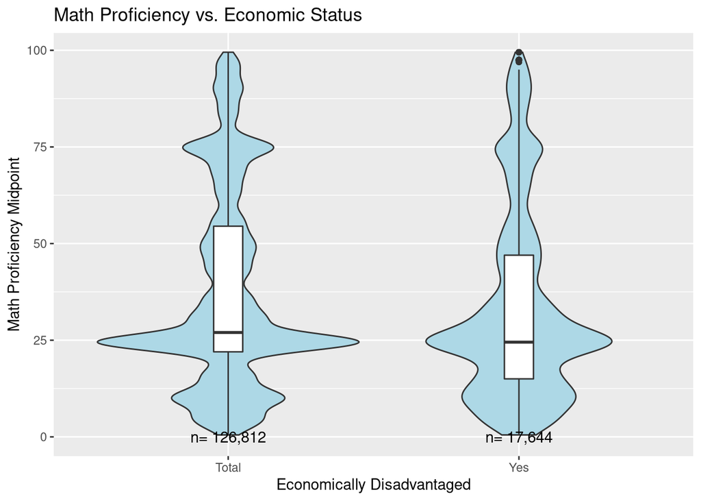

*Math Proficiency vs. Race*

Our previous model is a good start, but SES includes more than just economic information. We’d also like to explore the demographic dimensions (such as race and gender).

Unfortunately, our dataset only has the economically disadvantaged indicator populated for “total”. We don’t have information on combinations like “economically disadvantaged females”. We won’t be able to explore interactions between the variables given our one week time limit.

```
##
## Call:
## lm(formula = math_test_pct_prof_midpt ~ race, data = data_munged)
##
## Residuals:
##     Min      1Q  Median      3Q     Max
## -59.130 -19.963  -8.197  15.037  66.477
##
## Coefficients:
##              Estimate Std. Error t value Pr(>|t|)
## (Intercept)  35.19748    0.07901 445.474   <2e-16 ***
## raceWhite    11.73969    0.21339  55.014   <2e-16 ***
## raceBlack    -3.15818    0.28270 -11.172   <2e-16 ***
## raceHispanic -0.23400    0.24603  -0.951    0.342
## raceAsian    26.43251    0.37328  70.812   <2e-16 ***
## raceAI_AN    -6.67459    0.77904  -8.568   <2e-16 ***
## raceTwo_Plus 11.29867    0.37683  29.984   <2e-16 ***
## ---
## Signif. codes:  0 '***' 0.001 '**' 0.01 '*' 0.05 '.' 0.1 ' ' 1
##
## Residual standard error: 24.84 on 144449 degrees of freedom
## Multiple R-squared:  0.05707,    Adjusted R-squared:  0.05703
## F-statistic:  1457 on 6 and 144449 DF,  p-value: < 2.2e-16
```

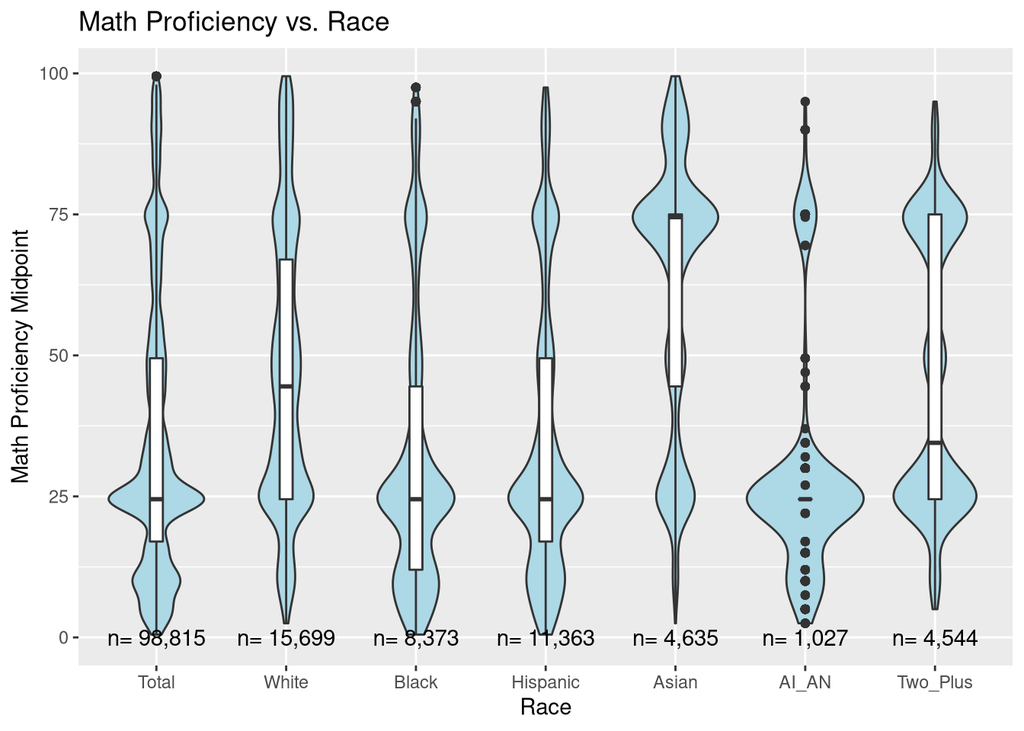

*Math Proficiency vs. Sex*

The displayed differences between sexes is also small. Students who identified as female on average outperformed those who identified as male by a minor margin.

```
##
## Call:
## lm(formula = math_test_pct_prof_midpt ~ sex, data = data_munged)
##
## Residuals:
##    Min     1Q Median     3Q    Max
## -41.68 -18.15 -10.35  15.85  63.35
##
## Coefficients:
##             Estimate Std. Error t value Pr(>|t|)
## (Intercept) 36.15362    0.07739  467.15   <2e-16 ***
## sexMale      4.19203    0.20409   20.54   <2e-16 ***
## sexFemale    6.02741    0.20565   29.31   <2e-16 ***
## ---
## Signif. codes:  0 '***' 0.001 '**' 0.01 '*' 0.05 '.' 0.1 ' ' 1
##
## Residual standard error: 25.48 on 144453 degrees of freedom
## Multiple R-squared:  0.007777,   Adjusted R-squared:  0.007763
## F-statistic: 566.1 on 2 and 144453 DF,  p-value: < 2.2e-16
```

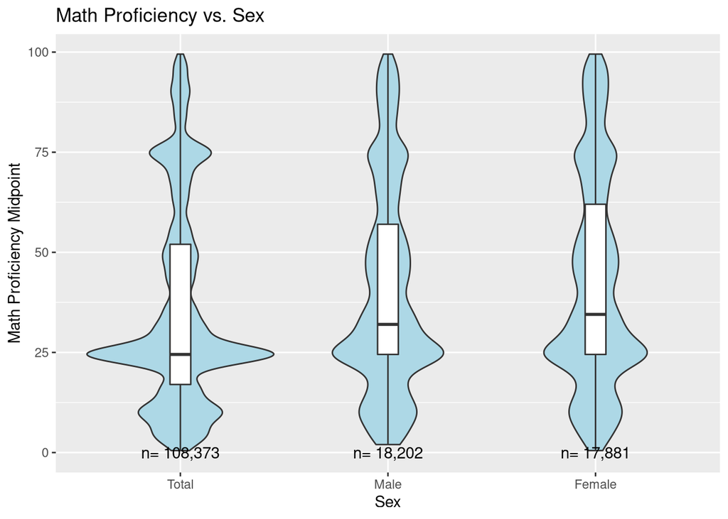

### Conclusions

We were able to extract some insights in overall patterns with regards to SES and academic performance. Specifically, we found small but a quantifiable differences between economically disadvantaged student populations and the overall student population. We also explored the differences in average performance between races and genders. However, limitations in our dataset prevented us from doing any analysis on interactions between these indicators.

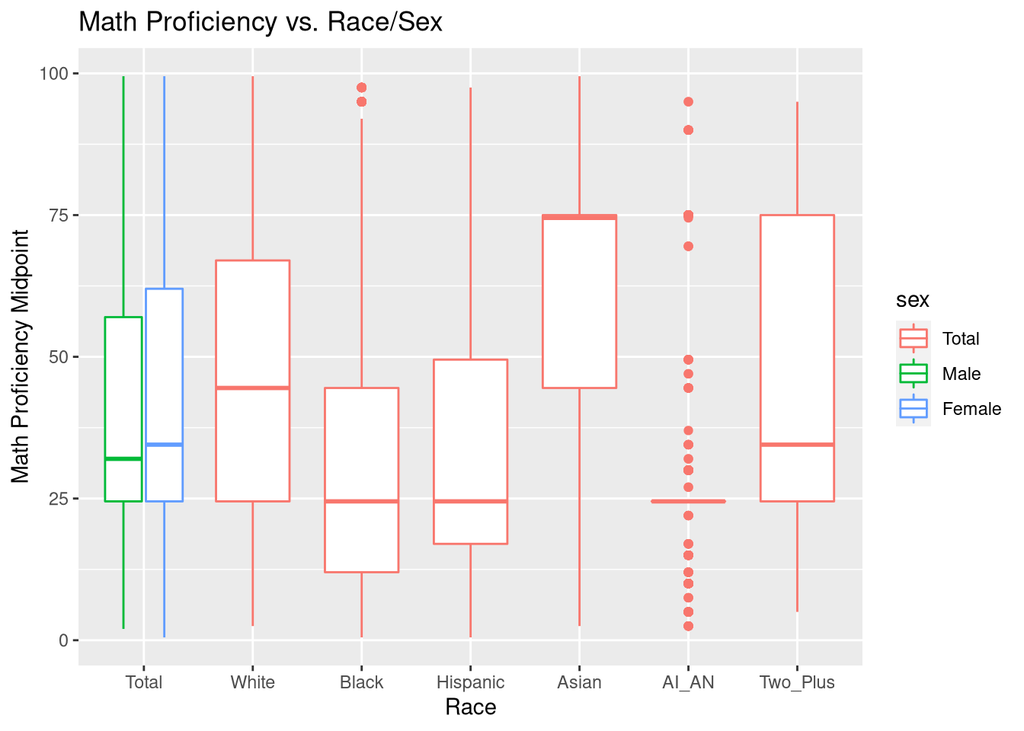

#### Appendix A: Comments on the Technical Stack

I primarily work in Python, but wanted to spend some time using R given its prevalence in industry. A few thoughts from this project are listed below in no particular order.

- Data filtering and selection is wonderful. Dplyr feels more natural than Pandas for many operations.
- For-loops over column names are [frustratingly obtuse](https://stackoverflow.com/questions/26003574/use-dynamic-variable-names-in-dplyr). The manner in which dataframe columns are referenced is all over the place; sometimes data[race] works, sometimes it must be data$race, or even 'data[$race]’.
- The implementation of regressions is handy. The related syntax for symbolic manipualation feels strange, but the convenience of "y~x1+x2+x1*x2" is well-worth the weirdness.
- Casting variables types is [not intuitive](https://www.geeksforgeeks.org/convert-factor-to-numeric-and-numeric-to-factor-in-r-programming/) at all. The default behavior of something like “as.factor(some_numeric_column)” is baffling.
- Likewise converting [character columns to factors](https://community.rstudio.com/t/is-it-normal-to-take-long-time-to-rename-factors/14965) using the default behavior takes an absurd amount of time. Achieving reasonable runtimes seems to require manually specifying the levels for each column, and then running a separate “relevel()” command.
- Special thanks to Dr. Scheithauer for publishing his [strategy](https://gscheithauer.medium.com/how-to-add-number-of-observations-to-a-ggplot2-boxplot-b22710f7ef80) for labelling box plots with counts, which we leveraged in our plots.

#### Appendix B: Reflections

This was intended to be a simple project to start off the practice problem series. And it was, though I spent more time figuring out R syntax than I would’ve liked. Hopefully the code used on these projects will gradually accumulate until the “how” of analysis takes less time than the “why”.

I should also spend some time reviewing my statistics fundamentals. This project applied very lightweight analysis; no curve-fitting, no fancy hypothesis testing, really just the plain output from R’s linear model. It’d be worthwhile to do some heavier work just for the sake of practice.

#### Footnotes

[^1]: The concept of “academic performance” is a complex discussion topic. To avoid getting side-tracked, we will declare an assumption that proficiency scores represent accurate representations of student ability.
[^2]: Astute readers will notice that the “Total” category includes more values than all other categories combined. This is a deliberate quality of the data; many schools have so few students of a given group that reporting statistics would amount to reporting identifying information. This is denoted in the dataset with a “-3”, and filtered out by our data munging pipeline.
[^3]: Race can be a contentious topic but it is a crucial focal point for many contemporary policy debates. For example, the [PASSNYC project](https://www.kaggle.com/passnyc/data-science-for-good) from 2018 was run in part to address long-standing debates on the fairness of NYC’s [secondary school admissions test](https://en.wikipedia.org/wiki/Specialized_High_Schools_Admissions_Test#Fairness) towards different races.